# CODE_BCCK

```python
# import các thư viện xử lý dữ liệu
import pandas as pd
import seaborn as sns
from sklearn.ensemble import RandomForestClassifier
from sklearn.naive_bayes import GaussianNB
from sklearn.svm import SVC
from sklearn.model_selection import train_test_split
from sklearn.metrics import accuracy_score
```

```python
# Load tập dữ liệu "crabs.csv"
crabs_df = pd.read_csv("crabs.csv")
# Hiển thị 5 dòng đầu tiên dữ liệu
crabs_df.head()
```

|  | sex | index | fontallip | rearwidth | length | width | depth | speies |
| --- | --- | --- | --- | --- | --- | --- | --- | --- |
| 0 | M | 1 | 8.1 | 6.7 | 16.1 | 19.0 | 7.0 | B |
| 1 | M | 2 | 8.8 | 7.7 | 18.1 | 20.8 | 7.4 | B |
| 2 | M | 3 | 9.2 | 7.8 | 19.0 | 22.4 | 7.7 | B |
| 3 | M | 4 | 9.6 | 7.9 | 20.1 | 23.1 | 8.2 | B |
| 4 | M | 5 | 9.8 | 8.0 | 20.3 | 23.0 | 8.2 | B |

```
array([[<AxesSubplot:title={'center':'index'}>,
        <AxesSubplot:title={'center':'fontallip'}>],
       [<AxesSubplot:title={'center':'rearwidth'}>,
        <AxesSubplot:title={'center':'length'}>],
       [<AxesSubplot:title={'center':'width'}>,
        <AxesSubplot:title={'center':'depth'}>]], dtype=object)
```

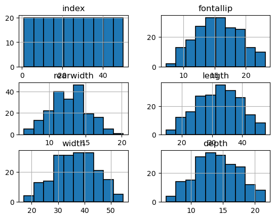

```python
# Vẽ histogram của các biến trong DataFrame crabs_df
crabs_df.hist(edgecolor='black', linewidth=1.2)
```

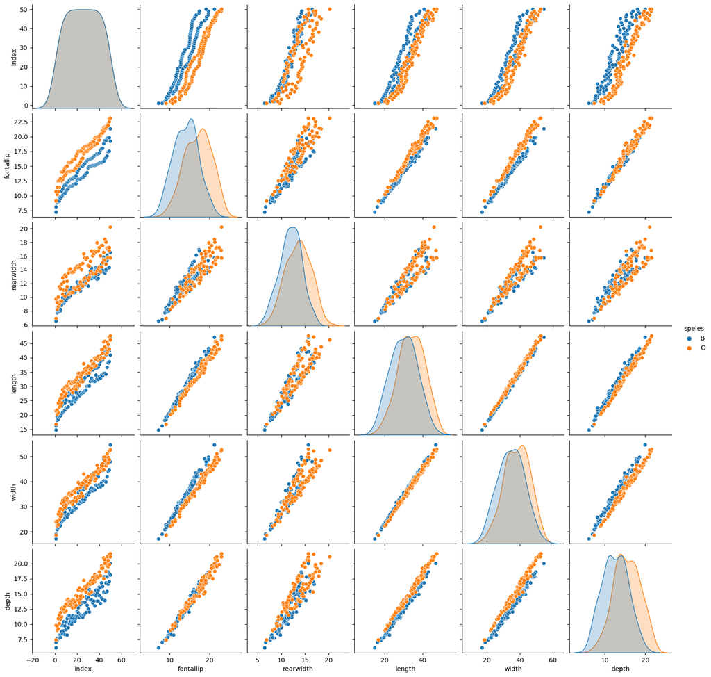

```python
#  Vẽ biểu đồ pairplot của các biến trong DataFrame cho thấy mối quan hệ hai biến giữa mỗi cặp đặc trưng.
sns.pairplot(crabs_df, hue="speies")
```

Biểu đồ này cho phép chúng ta quan sát mối quan hệ giữa từng cặp biến và xác định xem liệu có mối quan hệ tuyến tính hay phi tuyến tính giữa 2 loài

```python
# Chuẩn bị dữ liệu
X = crabs_df.drop(['speies'], axis=1)
y = crabs_df['speies']
```

```python
# hiện thị kích thước dữ liệu
print(crabs_df.shape)
```

```
(200, 8)
```

```python
# mô tả về các đặc trưng của dữ liệu
print(crabs_df.describe())
```

```
            index   fontallip  rearwidth      length       width       depth
count  200.000000  200.000000  200.00000  200.000000  200.000000  200.000000
mean    25.500000   15.583000   12.73850   32.105500   36.414500   14.030500
std     14.467083    3.495325    2.57334    7.118983    7.871955    3.424772
min      1.000000    7.200000    6.50000   14.700000   17.100000    6.100000
25%     13.000000   12.900000   11.00000   27.275000   31.500000   11.400000
50%     25.500000   15.550000   12.80000   32.100000   36.800000   13.900000
75%     38.000000   18.050000   14.30000   37.225000   42.000000   16.600000
max     50.000000   23.100000   20.20000   47.600000   54.600000   21.600000
```

```python
# Chọn các đặc trưng phù hợp để phân loại các loài cua
features = ['fontallip', 'rearwidth', 'length', 'width','depth']
```

```python
# Chia tập dữ liệu thành tập huấn luyện và tập kiểm tra
X_train, X_test, y_train, y_test = train_test_split(crabs_df[features], crabs_df['speies'], test_size=0.2,random_state=42)
```

```python
# Xây dựng mô hình Random Forest
rfc = RandomForestClassifier(n_estimators=100, random_state=42)
rfc.fit(X_train,y_train)
```

```
RandomForestClassifier(random_state=42)
```

Tham số n_estimators xác định số lượng cây quyết định được sử dụng trong mô hình random forest. Một giá trị lớn của n_estimators sẽ dẫn đến việc xây dựng một số lượng lớn các cây quyết định và tăng độ chính xác của mô hình, nhưng đồng thời cũng làm tăng thời gian huấn luyện và độ phức tạp của mô hình. Trong khi đó, một giá trị nhỏ của n_estimators có thể làm giảm độ chính xác của mô hình

```python
# Dự đoán nhãn cho tập kiểm tra
y_pred = rfc.predict(X_test)
```

```python
# áp dụng thuật toán Ramdon Forest hiển thị tính năng quan trọng ảnh hưởng đến việc phân loại cua
importance = rfc.feature_importances_
features = ['fontallip', 'rearwidth', 'length', 'width','depth']
df = pd.DataFrame({'features': features, 'importance': importance}).sort_values('importance', ascending=False)
print(df)
```

```
    features  importance
0  fontallip    0.265210
4      depth    0.235966
3      width    0.215257
2     length    0.170975
1  rearwidth    0.112592
```

Kết quả cho thấy : depth(chiều dày thân cua); fontallip( độ dài của thùy trước) ảnh hưởng đến việc nhận biết giữa 2 loại cua nhất

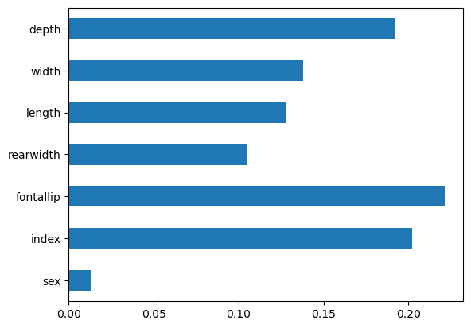

```python
crabs_df['speies'] = pd.factorize(crabs_df['speies'])[0]
crabs_df['sex'] = pd.factorize(crabs_df['sex'])[0]

# Chia tập dữ liệu thành tập huấn luyện và tập kiểm tra
train_data = crabs_df.sample(frac=0.8, random_state=1)
test_data = crabs_df.drop(train_data.index)

# Xác định các biến giải thích và biến mục tiêu
predictors = train_data.drop(['speies'], axis=1)
target = train_data['speies']

# Huấn luyện mô hình Random Forest
rf = RandomForestClassifier(n_estimators=1000, random_state=1)
rf.fit(predictors, target)

# Trích xuất tính năng quan trọng từ mô hình Random Forest
importances = pd.Series(rf.feature_importances_, index=predictors.columns)

# Trực quan hóa tính năng quan trọng bằng biểu đồ
importances.plot(kind='barh')
plt.show()
```

```python
# Tính độ chính xác của mô hình trên tập kiểm tra
accuracy = accuracy_score(y_test, y_pred)
print("Độ chính xác của mô hình là: {:.2f}%".format(accuracy * 100))
```

```
Độ chính xác của mô hình là: 90.00%
```

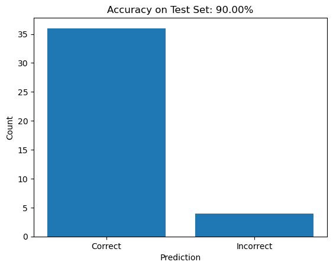

```python
import matplotlib.pyplot as plt

# Tính toán số lượng các giá trị dự đoán đúng và sai
correct = (y_pred == y_test).value_counts()[True]
incorrect = (y_pred == y_test).value_counts()[False]

# Hiển thị đồ thị độ chính xác
plt.bar(["Correct", "Incorrect"], [correct, incorrect])
plt.title("Accuracy on Test Set: {:.2f}%".format(accuracy*100))
plt.xlabel("Prediction")
plt.ylabel("Count")
plt.show()
```

```python
# Khởi tạo mô hình SVM với kernel là "rbf" và C là 1.0
svm = SVC(kernel="rbf", C=1.0)
svm.fit(X_train,y_train)
```

```
SVC()
```

Tham số C là một hệ số điều chỉnh độ quan trọng giữa việc tối đa hoá độ rộng của vùng giữa các lề và việc tối thiểu hóa sự mất mát của mô hình. Nếu giá trị của C lớn, mô hình sẽ cố gắng tối đa hoá độ rộng của vùng giữa các lề, đồng thời sẽ phải chấp nhận mất mát lớn hơn nếu các điểm dữ liệu không được phân loại đúng. Nếu giá trị của C nhỏ, mô hình sẽ tập trung vào việc giảm thiểu mất mát, đồng thời sẽ có vùng giữa các lề nhỏ hơn.

```python
# Dự đoán nhãn cho tập kiểm tra
y_pred = svm.predict(X_test)
```

```python
# Tính độ chính xác của mô hình trên tập kiểm tra
accuracy = accuracy_score(y_test, y_pred)
print("Độ chính xác của mô hình là: {:.2f}%".format(accuracy * 100))
```

```
Độ chính xác của mô hình là: 85.00%
```

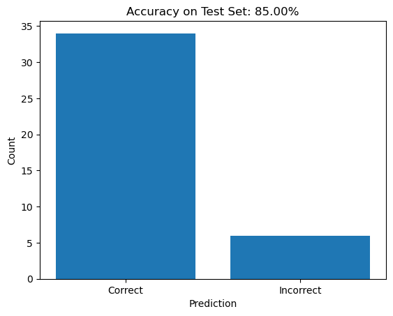

```python
import matplotlib.pyplot as plt

# Tính toán số lượng các giá trị dự đoán đúng và sai
correct = (y_pred == y_test).value_counts()[True]
incorrect = (y_pred == y_test).value_counts()[False]

# Hiển thị đồ thị độ chính xác
plt.bar(["Correct", "Incorrect"], [correct, incorrect])
plt.title("Accuracy on Test Set: {:.2f}%".format(accuracy*100))
plt.xlabel("Prediction")
plt.ylabel("Count")
plt.show()
```

```python
# Khởi tạo mô hình Naive Bayes và huấn luyện trên tập huấn luyện
gnb = GaussianNB()
gnb.fit(X_train, y_train)
```

```
GaussianNB()
```

```python
# Dự đoán nhãn cho tập kiểm tra
y_pred = gnb.predict(X_test)
```

```python
# Tính độ chính xác của mô hình trên tập kiểm tra
accuracy = accuracy_score(y_test, y_pred)
print("Độ chính xác của mô hình là: {:.2f}%".format(accuracy * 100))
```

```
Độ chính xác của mô hình là: 70.00%
```

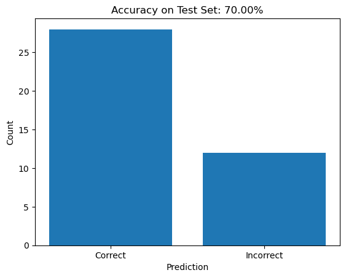

```python
import matplotlib.pyplot as plt

# Tính toán số lượng các giá trị dự đoán đúng và sai
correct = (y_pred == y_test).value_counts()[True]
incorrect = (y_pred == y_test).value_counts()[False]

# Hiển thị đồ thị độ chính xác
plt.bar(["Correct", "Incorrect"], [correct, incorrect])
plt.title("Accuracy on Test Set: {:.2f}%".format(accuracy*100))
plt.xlabel("Prediction")
plt.ylabel("Count")
plt.show()
```